# Using Fourier’s transform to model forest microclimates by playing the partition of temperature harmonics

### **The advantages of Fourier for dephasing and debiasing**

Beyond the extraction of multi-frequency amplitudes from temperature time series, the Fourier Transform also allows the extraction of signal phases, providing a better account of dephasing between signals across timescales. For instance, depending on the temporal resolution considered, soil temperature changes lag behind air temperature at short timescales owing to differences in thermal properties between media (Yin *et al.* 2024). In such cases, the offset and slope-equilibrium approaches introduce statistical noise, since the temperature measurements are no longer correctly time-matched: part of the variation around the offset, and around the slope-equilibrium regression, then reflects this time lag rather than microclimate buffering itself. By explicitly accounting for dephasing, the Fourier Transform resolves this issue (results not shown). We did not focus on the phase component of the decomposition here, but future studies could exploit it for phase-shift analysis, interpreting temporal offsets between macroclimate and microclimate signals as indicators of thermal inertia and canopy lag (e.g. Bush *et al.* 2016).

We first applied the Fourier Transform to microclimate assessment, as shown in study case 1. A further, less commonly discussed problem in microclimatology, and in applied climatology more broadly, is how to obtain a robust reference macroclimate product against which to estimate microclimate buffering. For instance, (Hes *et al.* 2025) corrected ERA5-Land reanalysis products in French Guiana against local MétéoFrance weather stations using a mean-and-variance correction, requiring separate corrections for each temporal frequency considered (hourly and monthly). We believe the Fourier Transform offers a clear advantage here for debiasing global macroclimate products against local data, as demonstrated in study case 2: it provides a fast, simple correction that remains robust across multiple timescales simultaneously. This approach is already used in several other domains: for example to correct CMIP6 simulations in climatology (Kusumastuti *et al.* 2022), to improve downscaling (Utami *et al.* 2024), or in hydrology (Kendall & Hyndman 2007), and we encourage its wider adoption in ecology and biogeography.

### **Limitations**

Like any approach, the Fourier Transform has limitations. Compared to the offset (De Freitas & Enright 1995) or slope-equilibrium (Gril *et al.* 2023b) approaches, which are increasingly adopted across a wide range of ecosystems and contexts, our approach still requires testing for scalability to other forest types and climates, in order to evaluate whether the Fourier Transform approach generalises beyond our three French study sites (Aigoual, Blois, Mormal). Methodologically, there is no specific reason for the Fourier Transform to be restricted to these cases, though this remains to be demonstrated; work in progress already suggests its suitability for tropical forests (Schmitt et al., in prep). A further limitation, not intrinsic to the Fourier Transform itself but to how we applied it, concerns the definition of the sliding window used in the analysis. Clear trade-offs exist between window length, frequency resolution, and sensitivity to transient weather events, and these warrant further investigation in microclimate ecology and biogeography, even though they have already been extensively studied in applied mathematics (e.g. Richardson & Eddy 2018).

### **Perspectives**

Given these limited limitations, we believe the Fourier Transform approach nonetheless holds strong potential for microclimate ecology and biogeography. Future directions include: (i) further exploration of higher-order harmonics and harmonic hierarchies; (ii) benchmarking the Fourier Transform against alternative downscaling methods; and (iii) making the method accessible through open-source tools.

Higher-order harmonics such as sub-daily cycles and harmonic hierarchies can reveal fine-scale buffering mechanisms beyond the dominant 24-hour period, such as stomatal dynamics identified from latent and sensible heat fluxes in an Amazonian forest (Pinheiro & Paulo 2011), and thus deserve further exploration. Similarly, while we focused here on macroclimate debiasing using a simple mean-and-variance correction for comparison (Hes *et al.* 2025), more advanced techniques exist, including quantile mapping (Cannon *et al.* 2015) or machine learning (Coulibaly *et al.* 2005) calling for a systematic benchmarking of Fourier Transform debiasing against these alternatives.

Finally, we believe that wider adoption of the Fourier Transform approach in microclimate ecology and biogeography will require making the method accessible through open-source tools, such as an R package, a format increasingly favoured by ecologists (Lai *et al.* 2019). This is a work in progress, with the active development of the R package *microclimr* and its associated application *microclimapp* (Schmitt et al., in prep), which also underlies the analyses presented in this paper (see Data availability).

### **Conclusion**

Taken together, our results show that the Fourier Transform is not merely an alternative to existing offset and slope-equilibrium approaches, but a methodological advance for microclimate ecology and biogeography. By resolving buffering across multiple timescales within a single, noise-robust framework, and by opening a path towards principled macroclimate debiasing, spectral decomposition addresses several limitations of current methods while remaining fully compatible with them. As microclimate data continues to be collected by sensor networks around the world, we believe that spectral approaches, such as the one presented here, and their future implementation in accessible, open-source tools, will become an increasingly valuable part of a microclimate ecologist’s toolkit.

## References

Becquerel, M. (1865). *Mémoire sur les forêts et leur influence climatérique*. Typographie du Firmin Didot frères, fils, et cie.

Bush, E.R., Abernethy, K.A., Jeffery, K., Tutin, C., White, L., Dimoto, E., Dikangadissi, J.-T., Jump, A.S. & Bunnefeld, N. (2016). Fourier analysis to detect phenological cycles using long-term tropical field data and simulations (R. Freckleton, Ed.). *Methods in Ecology and Evolution*, **8**, 530–540. Retrieved from http://dx.doi.org/10.1111/2041-210X.12704

Cannon, A.J., Sobie, S.R. & Murdock, T.Q. (2015). Bias Correction of GCM Precipitation by Quantile Mapping: How Well Do Methods Preserve Changes in Quantiles and Extremes? *Journal of Climate*, **28**, 6938–6959. Retrieved from http://dx.doi.org/10.1175/jcli-d-14-00754.1

Carlson, D.W. & Groot, A. (1997). Microclimate of clear-cut, forest interior, and small openings in trembling aspen forest. *Agricultural and Forest Meteorology*, **87**, 313–329.

Chen, J., Saunders, S.C., Crow, T.R., Naiman, R.J., Brosofske, K.D., Mroz, G.D., Brookshire, B.L. & Franklin, J.F. (1999). Microclimate in forest ecosystem and landscape ecology: Variations in local climate can be used to monitor and compare the effects of different management regimes. *BioScience*, **49**, 288–297.

Copernicus Climate Change Service. (2020). E-OBS daily gridded meteorological data for europe from 1950 to present derived from in-situ observations. Retrieved from https://cds.climate.copernicus.eu/doi/10.24381/cds.151d3ec6

Coulibaly, P., Dibike, Y.B. & Anctil, F. (2005). Downscaling Precipitation and Temperature with Temporal Neural Networks. *Journal of Hydrometeorology*, **6**, 483–496. Retrieved from http://dx.doi.org/10.1175/jhm409.1

De Freitas, C. & Enright, N. (1995). Microclimatic differences between and within canopy gaps in a temperate rainforest. *International Journal of Biometeorology*, **38**, 188–193.

De Frenne, P., Lenoir, J., Luoto, M., Scheffers, B.R., Zellweger, F., Aalto, J., Ashcroft, M.B., Christiansen, D.M., Decocq, G., De Pauw, K. & others. (2021). Forest microclimates and climate change: Importance, drivers and future research agenda. *Global change biology*, **27**, 2279–2297.

De Frenne, P., Zellweger, F., Rodrı́guez-Sánchez, F., Scheffers, B.R., Hylander, K., Luoto, M., Vellend, M., Verheyen, K. & Lenoir, J. (2019). Global buffering of temperatures under forest canopies. *Nature Ecology & Evolution*, **3**, 744–749.

Fressoz, J.-B. & Locher, F. (2020). *Les révoltes du ciel: Une histoire du changement climatique XVe-XXe siècle* (L. Seuil, Ed.). Cairn.info. Retrieved fromhttps://shs.cairn.info/les-revoltes-du-ciel--9782021058147?lang=fr

Fuster, J.J.N. (1845). *Des changements dans le climat de la france. Histoire de ses révolutions météorologiques*. Capelle, Libraire-Éditeur.

Geiger. (1965). *The climate near the ground*. Harvard University Press.

Gril, E., Laslier, M., Gallet-Moron, E., Durrieu, S., Spicher, F., Le Roux, V., Brasseur, B., Haesen, S., Van Meerbeek, K., Decocq, G., Marrec, R. & Lenoir, J. (2023a). Using airborne LiDAR to map forest microclimate temperature buffering or amplification. *Remote Sensing of Environment*, **298**, 113820. Retrieved from http://dx.doi.org/10.1016/j.rse.2023.113820

Gril, E., Spicher, F., Greiser, C., Ashcroft, M.B., Pincebourde, S., Durrieu, S., Nicolas, M., Richard, B., Decocq, G., Marrec, R. & others. (2023b). Slope and equilibrium: A parsimonious and flexible approach to model microclimate. *Methods in Ecology and Evolution*, **14**, 885–897.

Gril, E., Spicher, F., Vanderpoorten, A., Gallet-Moron, E., Brasseur, B., Le Roux, V., Laslier, M., Decocq, G., Marrec, R. & Lenoir, J. (2025). The affinity of vascular plants and bryophytes to forest microclimate buffering. *Journal of Ecology*, **113**, 22–38.

Gril, E., Spicher, F., Vanderpoorten, A., Vital, G., Brasseur, B., Gallet-Moron, E., Le Roux, V., Decocq, G., Lenoir, J. & Marrec, R. (2024). Ecological indicator values of understorey plants perform poorly to infer forest microclimate temperature. *Journal of Vegetation Science*, **35**. Retrieved from http://dx.doi.org/10.1111/jvs.13241

Hes, G., Badouard, V., Burban, B., Cazal, J., Courtois, E.A., Derroire, G., Francoise, L., Goret, J.-Y., Mirabel, A., Naisso, P. & others. (2025). East amazon forest understory temperatures reached a record high in 2023–2024. *Scientific Reports*.

Kaspari, M. (2019). In a globally warming world, insects act locally to manipulate their own microclimate. *Proceedings of the National Academy of Sciences*, **116**, 5220–5222. Retrieved from http://dx.doi.org/10.1073/pnas.1901972116

Kemppinen, J., Lembrechts, J.J., Van Meerbeek, K., Carnicer, J., Chardon, N.I., Kardol, P., Lenoir, J., Liu, D., Maclean, I., Pergl, J. & others. (2024). Microclimate, an important part of ecology and biogeography. *Global Ecology and Biogeography*, **33**, e13834.

Kendall, A.D. & Hyndman, D.W. (2007). Examining watershed processes using spectral analysis methods including the scaled-windowed fourier transform. pp. 183–200. American Geophysical Union. Retrieved from http://dx.doi.org/10.1029/171GM14

Kusumastuti, C., Jiang, Z., Mehrotra, R. & Sharma, A. (2022). Correcting Systematic Bias in Climate Model Simulations in the Time-Frequency Domain. *Geophysical Research Letters*, **49**. Retrieved from http://dx.doi.org/10.1029/2022GL100550

Lai, J., Lortie, C.J., Muenchen, R.A., Yang, J. & Ma, K. (2019). Evaluating the popularity of R in ecology. *Ecosphere*, **10**. Retrieved from http://dx.doi.org/10.1002/ecs2.2567

Lenoir, J., Gril, E., Spicher, F., Brasseur, B., Marrec, R., Le Roux, V., Mahier, H., Vital, G., Châline, A. & Hayé, H. (2024). Temperature time series of mormal, blois and aigoual forests. Retrieved from https://data.indores.fr:443/citation?persistentId=doi:10.48579/PRO/ZQBQUW

Maclean, I.M.D., Duffy, J.P., Haesen, S., Govaert, S., De Frenne, P., Vanneste, T., Lenoir, J., Lembrechts, J.J., Rhodes, M.W. & Van Meerbeek, K. (2021). On the measurement of microclimate. *Methods in Ecology and Evolution*, **12**, 1397–1410. Retrieved from http://dx.doi.org/10.1111/2041-210X.13627

Muñoz-Sabater, J., Dutra, E., Agustí-Panareda, A., Albergel, C., Arduini, G., Balsamo, G., Boussetta, S., Choulga, M., Harrigan, S., Hersbach, H., Martens, B., Miralles, D.G., Piles, M., Rodríguez-Fernández, N.J., Zsoter, E., Buontempo, C. & Thépaut, J.-N. (2021). ERA5-Land: a state-of-the-art global reanalysis dataset for land applications. *Earth System Science Data*, **13**, 4349–4383. Retrieved from http://dx.doi.org/10.5194/essd-13-4349-2021

Pincebourde, S. & Casas, J. (2019). Narrow safety margin in the phyllosphere during thermal extremes. *Proceedings of the National Academy of Sciences*, **116**, 5588–5596. Retrieved from http://dx.doi.org/10.1073/pnas.1815828116

Pinheiro, M.R. & Paulo, S.R. de. (2011). Utilização da análise de FOURIER no estudo de variáveis micrometeorológicas de uma floresta de transição do norte de mato grosso. *Acta Amazonica*, **41**, 39–46. Retrieved from http://dx.doi.org/10.1590/S0044-59672011000100005

Richardson, L.F. & Eddy, W.F. (2018). The sliding window discrete fourier transform. Retrieved from https://arxiv.org/abs/1807.07797

Sorre, M. (1961). La notion de micro-climat. *Bulletin de l’Association de géographes français*, **38**, 162–169.

Utami, T.W., Gufron, A. & Fauzi, F. (2024). Fourier Series Approach for Bias Correction in Statistical Downscaling Methods. pp. 171–183. Atlantis Press International BV. Retrieved from http://dx.doi.org/10.2991/978-94-6463-480-8_14

Wild, J., Kopecký, M., Macek, M., Šanda, M., Jankovec, J. & Haase, T. (2019). Climate at ecologically relevant scales: A new temperature and soil moisture logger for long-term microclimate measurement. *Agricultural and Forest Meteorology*, **268**, 40–47. Retrieved from http://dx.doi.org/10.1016/j.agrformet.2018.12.018

Yin, H., Wu, Z., Huang, Z., Luo, Y., Liu, X., Peng, X. & Li, Q. (2024). A multivariate soil temperature interval forecasting method for precision regulation of plant growth environment. *Frontiers in Plant Science*, **15**. Retrieved from http://dx.doi.org/10.3389/fpls.2024.1460654

Zellweger, F., Coomes, D., Lenoir, J., Depauw, L., Maes, S.L., Wulf, M., Kirby, K.J., Brunet, J., Kopecký, M., Máliš, F., Schmidt, W., Heinrichs, S., Ouden, J. den, Jaroszewicz, B., Buyse, G., Spicher, F., Verheyen, K. & De Frenne, P. (2019). Seasonal drivers of understorey temperature buffering in temperate deciduous forests across Europe (A. Algar, Ed.). *Global Ecology and Biogeography*, **28**, 1774–1786. Retrieved from http://dx.doi.org/10.1111/geb.12991

## Supplementary material

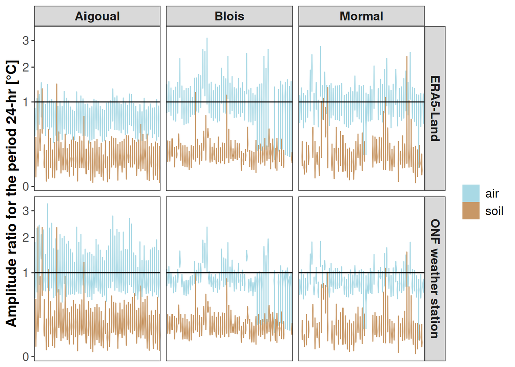

Figure 6: The amplitude ratio for the 24-hour period between May and September from 2020 to 2023 for air and soil sensors in the Mormal, Blois and Aigoual forests, for ONF and ERA5-Land macroclimate data.

```r
buffers <- read_tsv("data/decomposition.tsv") %>%
  filter(period == 12) %>%
  select(source, site, plot, sensor, position, pai, power, datetime) %>%
  pivot_wider(names_from = source, values_from = power) %>%
  mutate(ratio_era = hobo / era, ratio_onf = hobo / onf) %>%
  select(-era, -hobo, -onf) %>%
  gather(source, ratio, -site, -plot, -sensor, -pai, -datetime, -position) %>%
  mutate(source = gsub("ratio_", "", source))
buffers %>%
  mutate(source = recode(source,
    "era" = "ERA5-Land",
    "onf" = "ONF weather station"
  )) %>%
  ggplot(aes(plot, ratio, fill = position, col = position)) +
  geom_violin() +
  facet_grid(source ~ site, scales = "free_x") +
  theme_bw() +
  theme(panel.grid = element_blank()) +
  geom_hline(yintercept = 1) +
  theme(
    axis.text.x = element_blank(),
    axis.title.x = element_blank(),
    axis.ticks.x = element_blank(),
    axis.text.y = element_text(size = 12),
    axis.title.y = element_text(size = 14, face = "bold"),
    strip.text = element_text(size = 12, face = "bold"),
    legend.text = element_text(size = 12)
  ) +
  ylab("Amplitude ratio for the period 24-hr [°C]") +
  scale_y_sqrt() +
  scale_fill_manual("", values = c("#a9d9e5", "#c89867")) +
  scale_color_manual("", values = c("#a9d9e5", "#c89867"))
```

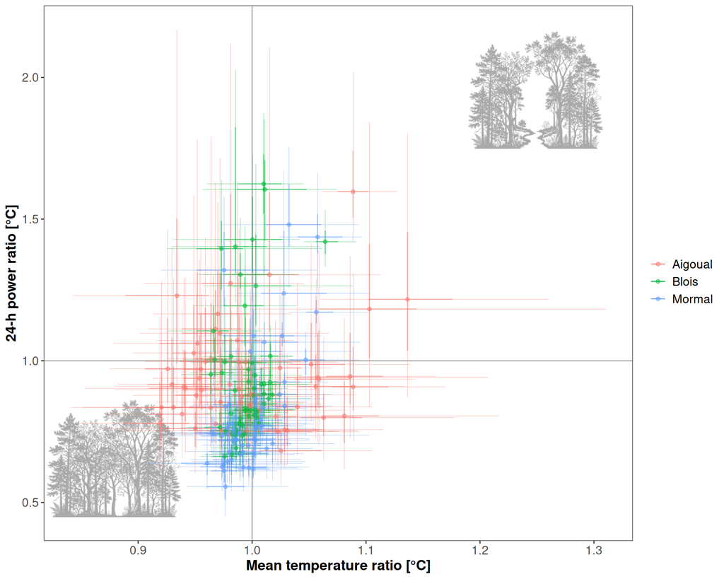

Figure 7: Mean temperature ratio vs. 24-h power ratio between microclimate (numerator) and macroclimate (denominator) conditions across forest plots for the three studied forests. Microclimate conditions were recorded inside forest plots equipped with HOBO sensors for air (1 m height) temperature. Macroclimate conditions refer to air temperature measured by ONF weather stations located nearby each of the three studied state forests: Aigoual, Blois and Mormal. The point represents the median, the thick line the 50 percent distribution and the thin line the 90 percent distribution.

```r
g <- read_tsv("data/decomposition.tsv") %>%
  filter(source != "era") %>%
  filter(period %in% c(0, 12)) %>%
  select(-amplitude, -phase, -frequency) %>%
  pivot_wider(names_from = source, values_from = power) %>%
  na.omit() %>%
  mutate(ratio = hobo / onf) %>%
  select(-hobo, -onf) %>%
  mutate(period = paste0("period_", period)) %>%
  group_by(position, site, plot, period) %>%
  summarise(
    q05 = quantile(ratio, .05),
    q25 = quantile(ratio, .25),
    q5 = quantile(ratio, .5),
    q75 = quantile(ratio, .75),
    q95 = quantile(ratio, .95)
  ) %>%
  gather(metric, value, -position, -site, -plot, -period) %>%
  mutate(period_metric = paste0(period, "_", metric)) %>%
  select(-period, -metric) %>%
  pivot_wider(names_from = period_metric, values_from = value) |>
  filter( position == "air") |>
  ggplot(aes(period_0_q5, period_12_q5, col = site)) +
  ggimage::geom_image(data = tibble(period_0_q5 = 1.3,
                                    period_12_q5 = 1.95, site = "Aigoual"),
                      aes(image = "figs/gap.png"), size = 0.5, col = "darkgrey") +
  ggimage::geom_image(data = tibble(period_0_q5 = 0.93,
                                    period_12_q5 = 0.65, site = "Aigoual"),
                      aes(image = "figs/forest.png"), size = 0.5, col = "darkgrey") +
  geom_vline(xintercept = 1, col = "darkgrey") +
  geom_hline(yintercept = 1, col = "darkgrey") +
  geom_segment(aes(x = period_0_q25, xend = period_0_q75), alpha = .5) +
  geom_segment(aes(x = period_0_q05, xend = period_0_q95), linewidth = .2, alpha = .5) +
  geom_segment(aes(y = period_12_q25, yend = period_12_q75), alpha = .5) +
  geom_segment(aes(y = period_12_q05, yend = period_12_q95), linewidth = .2, alpha = .5) +
  geom_point(alpha = .5) +
  theme_bw() +
  theme(panel.grid = element_blank()) +
  xlab("Mean temperature ratio [°C]") +
  ylab("24-h power ratio [°C]") +
  theme(
    axis.text = element_text(size = 12),
    axis.title = element_text(size = 14, face = "bold"),
    legend.text = element_text(size = 12)
  ) +
  scale_color_discrete("")
cowplot::save_plot("figs/buffer3.png",
                   plot = g,
                   base_width = 10,
                   base_height = 8,
                   dpi = 300,
                   bg = "white"
)
g
```